# SA out degree and clustering neighborhood size versus risk level

Erik Volz

April 4, 2016

This looks at baseline simulations and determines ability of SA & clustering to detect different transmissoin rates by risk level.

An important difference between this analysis and previous analyses is that there is no correlation between risk level and age of infection; this is by design in the simulation experiments. So we may expect clustering to do better, and indeed it does.

Load data

```r
# we can re-use out degree computed from teh age analysis, but we need to derive the risk level for each sample:
load('age-anal0.0.RData')
```

Helper function for finding risk level for each sample:

```r
deme2rl <- function(deme){as.numeric( substr(regmatches( deme , regexpr( 'riskLevel[0-9]', deme )), 10,10) ) }
#~  ensure fns in same order as fns2agemat_tables
ratesBaselineFNS <- list.files('RData', full.names=T, path = 'model0-simulateBaseline0')
```

Load the data tables and add risk level information

```r
odtabs <- list()
for (itab in 1:length( fns2agemat_tables ) )
{
    fn <- ratesBaselineFNS[itab]
    tab <- fns2agemat_tables[[itab]]$tab
    load(fn) #sampleDemes
    rls <- sapply( sampleDemes[ rownames(tab) ], deme2rl )
    tab <- cbind( tab, rls )
    odtabs[[itab]] <- tab
}
```

Now test if risk level has significant association with out degree and/or neighborhood size. We will do this with two tests for both outcomes:

- A univariate test using Mann Whitney U
- A multivariate test using linear or non-linear regression. This analysis adjusts for stage of infection which is the main other source of variance in transmission rates.

```r
sa_univariate_ps <- c()
sa_multivariate_ps <- c()
cl_multivariate_ps <- c()
cl_univariate_ps <- c()
# helper function to get p value in multivariate models
.lr.summary2rl.p <- function(s)
{
    scoef <- coef( s )
    scoef[rownames(scoef)=='scale(rls)', ncol(scoef)]
}
for (tab in odtabs)
{
    # NOTE that find OD analyses work better if excluding zeros; performance of clustering is not affected
    tab <- tab[ tab$od > 0 ,]

    od1 <- tab$od[ tab$rls==1]
    od2 <- tab$od[ tab$rls==2]
    sa_univariate_ps <- c( sa_univariate_ps, wilcox.test( od1, od2 , alternative='less')$p.value )
    #lr_sa <- summary( lm( scale(od) ~ scale(rls) * as.factor(stage), data = tab) )
    # I find that the log-transformed OD works better:
    lr_sa <- summary( lm( scale(log(od)) ~ scale(rls) * as.factor(stage), data = tab) )
    sa_multivariate_ps <- c( sa_multivariate_ps, .lr.summary2rl.p( lr_sa ))

    cs1 <- tab$nbrhoodSize[tab$rls==1]
    cs2 <- tab$nbrhoodSize[tab$rls==2]
    cl_univariate_ps <- c( cl_univariate_ps, wilcox.test( cs1, cs2 , alternative='less')$p.value )
    lr_cl <- summary( lm( scale(nbrhoodSize) ~ scale(rls) * as.factor(stage), data = tab) )
    cl_multivariate_ps <- c( cl_multivariate_ps, .lr.summary2rl.p( lr_cl ))
}

summary( sa_univariate_ps )
```

```
##      Min.   1st Qu.    Median      Mean   3rd Qu.      Max.
## 0.0000001 0.0001111 0.0011160 0.0092930 0.0049180 0.1314000
```

```r
summary( sa_multivariate_ps )
```

```
##    Min. 1st Qu.  Median    Mean 3rd Qu.    Max.
## 0.00000 0.00236 0.12760 0.25640 0.44890 0.96600
```

```r
summary( cl_univariate_ps )
```

```
##      Min.   1st Qu.    Median      Mean   3rd Qu.      Max.
## 0.000e+00 0.000e+00 0.000e+00 3.089e-09 3.000e-14 1.726e-07
```

```r
summary( cl_multivariate_ps )
```

```
##      Min.   1st Qu.    Median      Mean   3rd Qu.      Max.
## 0.0000233 0.0061630 0.0430900 0.1860000 0.3073000 0.9755000
```

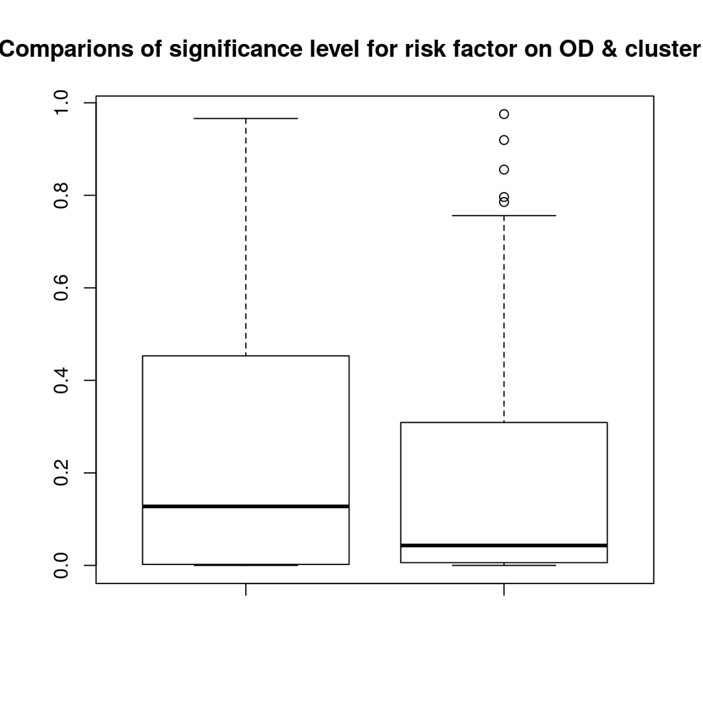

```r
boxplot( sa_multivariate_ps, cl_multivariate_ps , main = 'Comparions of significance level for risk factor on OD & cluster size')
```

Proportion of univariate tests that correctly detect difference in transmission rates

- SA: 0.94
- Neighborhood size: 1

Proportion of multivariate tests that correctly detect difference in transmission rates

- SA: 0.4
- Neighborhood size: 0.52

# Conclusions

- Clustering has slightly more power to detect effect of *risk level*
- Both methods have high sensitivity in univariate analyses, but if adjusting for other factors like stage of infection, performance drops dramatically.
- The difference in out degree and cluster size comparing risk levels 1 & 2 is very small, despite a 10-fold difference in rates!
- Neither method can quantitavely estimates the magnitude of the rate difference

This leads to the following predictions for the real data: for variables like CHIC enrollment, we may see a larger difference with clustering than for source attribution.